# FigureYa203ComBat

**Author(s)**: Xiaofan Lu  
**Reviewer(s)**: Ying Ge, Yasi Zhang  
**Date**: 2025-12-18

## 1 Academic Citation

If you use this code in your work or research, we kindly request that you cite our publication:

Xiaofan Lu, et al. (2025). FigureYa: A Standardized Visualization Framework for Enhancing Biomedical Data Interpretation and Research Efficiency. iMetaMed. https://doi.org/10.1002/imm3.70005

## 2 需求描述 Requirement description

想实现这篇文章里的数据处理方法，TCGA的RNA-seq数据和不同平台的microarray数据合并及标准化，希望能够得到相对统一的处理方式。

We would like to process the data as the methods described in this article, specifically the merging and normalization of TCGA RNA-seq data and microarray data from different platforms, hoping to achieve a relatively unified processing approach.

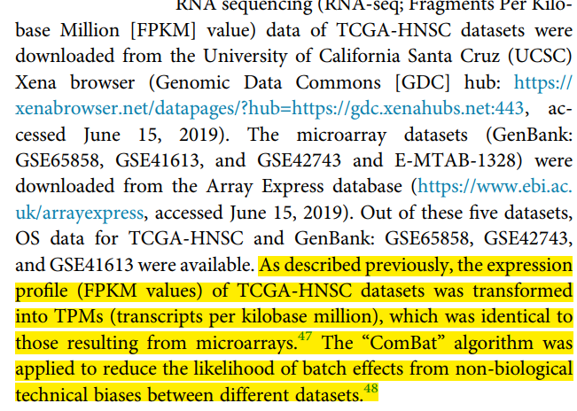

跟FigureYa201ClusterCorrelation出自同一篇文章，出自：https://www.cell.com/molecular-therapy-family/nucleic-acids/fulltext/S2162-2531(20)30259-6

This is from the same article as FigureYa201ClusterCorrelation, originally published in: https://www.cell.com/molecular-therapy-family/nucleic-acids/fulltext/S2162-2531(20)30259-6

## 3 应用场景 Application scenarios

不同平台的表达谱去除批次效应，绘制PCA图查看效果。

这里采用的是R包sva中的ComBat。

另外，还有一些文章采用非经典的去除批次效应的方式，例如FigureYa117multilinearDE。

Remove batch effects from expression profiles across different platforms and visualize the results using PCA plots.

Here, the ComBat method from the sva R package was used.

Additionally, some studies employ non-classical batch effect removal approaches, such as FigureYa117multilinearDE.

## 4 环境设置 Environment settings

```r
source("install_dependencies.R")
```

```
## Starting R package installation for FigureYa203ComBat...
## ===========================================
##
## Installing Bioconductor packages...
## Package already installed: TCGAbiolinks
## Package already installed: sva
## Package already installed: SummarizedExperiment
## Package already installed: edgeR
## Package already installed: ClassDiscovery
## Package already installed: oompaBase
##
## Installing CRAN packages...
## Package already installed: cluster
##
## ===========================================
## Package installation completed!
```

```r
library(TCGAbiolinks) # TCGA数据下载工具 TCGA data download tool
library(sva) # 批次效应校正工具 Batch effect correction tool
```

```r
library(cluster) # 聚类分析工具 Clustering analysis tool
library(oompaBase) # 绘图工具 Plotting tool
library(SummarizedExperiment) # 数据结构工具 Data structure tool
library(edgeR) # 差异表达分析工具 Differential expression analysis tool
source("batchPCA.R") # 加载绘制PCA图的自定义函数 Load custom function for PCA plotting

Sys.setenv(LANGUAGE = "en") # 显示英文报错信息 Show English error messages
options(stringsAsFactors = FALSE) # 禁止chr转成factor Prevent character-to-factor conversion
```

## 5 输入文件 Input files

这里以一种TCGA肿瘤和两套GEO芯片数据为例，处理更多数据集的方式也是一样的。

如果你的表达矩阵已处理成easy_input_TCGA.csv和easy_input_GSE*.csv的格式，就可以跳过这步，直接进入“检查数据的量级”。

Here, we use one TCGA tumor dataset and two GEO microarray datasets as examples, but the same approach applies to processing more datasets.

If your expression matrices have already been formatted as easy_input_TCGA.csv and easy_input_GSE*.csv, you can skip this step and proceed directly to “Checking Data Magnitude.

```r
## TCGA数据下载及预处理 TCGA data download and preprocessing
# 查询TCGA头颈鳞癌RNA-seq数据(STAR比对原始计数) Query TCGA HNSC RNA-seq data (STAR-aligned raw counts)
expquery <- GDCquery(project = "TCGA-HNSC",
                     data.category = "Transcriptome Profiling",
                     data.type = "Gene Expression Quantification",
                     workflow.type = "STAR - Counts")
```

```
## o GDCquery: Searching in GDC database
```

```
## Genome of reference: hg38
```

```
## oo Accessing GDC. This might take a while...
```

```
## ooo Project: TCGA-HNSC
```

```
## oo Filtering results
```

```
## ooo By data.type
```

```
## ooo By workflow.type
```

```
## oo Checking data
```

```
## ooo Checking if there are duplicated cases
```

```
## ooo Checking if there are results for the query
```

```
## o Preparing output
```

```r
# 下载查询到的数据到本地"GDCdata"文件夹
# Download the queried data to local "GDCdata" folder
GDCdownload(expquery, directory = "GDCdata")
```

```
## GDCdownload will download 566 files. A total of 2.395352858 GB
```

```
## The total size of files is big. We will download files in chunks
```

[output not shown]

[output not shown]

[output not shown]

```r
# 准备数据并加载为SummarizedExperiment对象
# Prepare and load the data into R as SummarizedExperiment object
expdata <- GDCprepare(expquery, directory = "GDCdata")
```

```
## Starting to add information to samples
```

```
##  => Add clinical information to samples
```

```
##  => Adding TCGA molecular information from marker papers
```

```
##  => Information will have prefix 'paper_'
```

```
## hnsc subtype information from:doi:10.1038/nature14129
```

```
## Available assays in SummarizedExperiment :
##   => unstranded
##   => stranded_first
##   => stranded_second
##   => tpm_unstrand
##   => fpkm_unstrand
##   => fpkm_uq_unstrand
```

```r
# 1. TPM
# 1. TPM
tpmMatrix <- assay(expdata, "tpm_unstrand")
tumorSamples <- colnames(tpmMatrix)[substr(colnames(tpmMatrix), 14, 15) == "01"]
tpmMatrix <- tpmMatrix[, tumorSamples]

tpms <- as.data.frame(round(tpmMatrix, 2))

# 2. 基因注释（假设已有overlapTable27.txt文件）
# 2. Gene annotation (assuming overlapTable27.txt exists)
Ginfo <- read.table("overlapTable27.txt", sep = "\t", row.names = 1,
                    header = TRUE, check.names = FALSE)

# 匹配基因并取均值
# Match genes and take average expression
rownames(Ginfo) <- Ginfo$gene_id
commonGenes <- intersect(rownames(tpms), rownames(Ginfo))
tpms <- tpms[commonGenes, ]
Ginfo <- Ginfo[commonGenes, ]

# 按基因符号聚合(取表达均值)
# Aggregate by gene symbol (average expression)
tpms$Gene <- Ginfo$genename
tpms.hugo <- aggregate(. ~ Gene, data = tpms, FUN = mean, na.rm = TRUE)
rownames(tpms.hugo) <- tpms.hugo$Gene
tpms.hugo$Gene <- NULL

# 保存处理后的数据
# Save processed data
write.csv(tpms.hugo, "easy_input_TCGA.csv", quote = FALSE)

unlink("GDCdata", recursive = TRUE)

## GEO芯片数据下载及预处理
## Downloading and Preprocessing GEO Microarray Data
## 这里用sangerbox下载GEO表达谱数据及预处理，方法见`GEO_sangerbox.docx`文件。生成`gse41613.expr.txt`以及`gse65858.expr.txt`后进行如下处理。
##（还可以用`FigureYa59Plus_GEO2DEG`下载GEO芯片数据并预处理，获得表达矩阵easy_input_expr.csv文件）
## Here, we use SangerBox to download and preprocess GEO expression data, as detailed in the `GEO_sangerbox.docx` file. After generating `gse41613.expr.txt` and `gse65858.expr.txt`, proceed with the following steps.
## (Alternatively, you can use `FigureYa59Plus_GEO2DEG` to download and preprocess GEO microarray data, obtaining the expression matrix file easy_input_expr.csv)
# GSE41613数据集处理
# GSE41613 Dataset Processing
gse41613.expr <- read.delim("gse41613.expr.txt",sep = "\t",row.names = 1,check.names = F,stringsAsFactors = F,header = T)

# Inspect the format - notice multiple gene mappings separated by "///" (Important: Check in Excel but NEVER save modifications)
# 检查数据格式 - 注意行名中存在"///"分隔的多基因匹配（重要提示：可在Excel中检查但不要保存任何修改）
gse41613.expr[1:3,1:3]
```

```
##                           GSM1020099 GSM1020100 GSM1020101
## T                           3.357284   3.233885   3.294725
## KRTAP4-6 /// LOC101930568   2.209291   2.196135   2.220619
## OSCP1                       2.598729   2.545430   2.610215
```

```r
# 提取///符号前的首要基因名
# Extract primary gene symbol (before "///")
gse41613.expr$Gene <- sapply(strsplit(rownames(gse41613.expr)," /// ",fixed = T),"[",1)

# 按基因名聚合多探针（取均值）
# Aggregate multiple probes by gene symbol (take mean)
gse41613.expr <- apply(gse41613.expr[,setdiff(colnames(gse41613.expr), "Gene")], 2, function(x) tapply(x, INDEX=factor(gse41613.expr$Gene), FUN=mean, na.rm=TRUE))

# 格式化并保存
# Format and save
gse41613.expr <- as.data.frame(round(gse41613.expr,2))
write.csv(gse41613.expr, "easy_input_GSE41613.csv", quote = F)

# GSE65858数据集处理
# GSE65858 Dataset Processing
gse65858.expr <- read.delim("gse65858.expr.txt",sep = "\t",row.names = 1,check.names = F,stringsAsFactors = F,header = T)

# 检查显示基因名规范无需处理
# Inspection shows clean gene symbols - no need for processing
gse65858.expr[1:3,1:3]
```

```
##       GSM1607684 GSM1607685 GSM1607686
## T         6.3893    6.43350     6.3609
## OSCP1     6.7796    6.70155     6.4841
## AR        6.6656    6.77180     6.4247
```

```r
gse65858.expr <- as.data.frame(round(gse65858.expr,2))
write.csv(gse65858.expr, "easy_input_GSE65858.csv", quote = F)
```

## 6 检查两类数据的量级 Checking data magnitude

通过取对数，让两类数据的数量级达到同一范围。

By taking the logarithm, we adjust the two types of data to the same magnitude range.

```r
# TCGA RNA-seq数据处理
# TCGA RNA-seq Data Processing
tpms.hugo <- read.csv("easy_input_TCGA.csv", row.names = 1)
tpms.hugo[1:3, 1:3]
```

```
##           TCGA.CQ.6221.01A.11R.2081.07 TCGA.IQ.7631.01A.11R.2081.07
## 5_8S_RRNA                    0.0000000                   0.00000000
## 5S_RRNA                      0.2166667                   0.07866667
## 7SK                          0.0000000                   0.00000000
##           TCGA.CV.7406.01A.11R.2081.07
## 5_8S_RRNA                    0.0000000
## 5S_RRNA                      0.2473333
## 7SK                          0.0000000
```

```r
range(tpms.hugo)
```

```
## [1]      0.0 167768.3
```

```r
# 对数转换(加1伪计数避免负无穷)
# Log2 transformation (pseudocount +1 to avoid -Inf) /
tcga.expr <- log2(tpms.hugo + 1)
range(tcga.expr)
```

```
## [1]  0.00000 17.35612
```

```r
# GEO芯片数据加载
# GEO Microarray Data Loading
gse41613.expr <- read.csv("easy_input_GSE41613.csv", row.names = 1)
gse65858.expr <- read.csv("easy_input_GSE65858.csv", row.names = 1)

# 检查芯片数据范围
# Check microarray value ranges
range(gse41613.expr)
```

```
## [1]  1.24 16.24
```

```r
range(gse65858.expr)
```

```
## [1]  5.38 14.26
```

## 7 合并数据集、检查批次效应 Merging datasets and checking batch effects

```r
# 设置颜色方案
# Set color palette
blue <- "#2874C5"
yellow <- "#EABF00"
green <- "#008B8A"

# 提取在三套数据中都出现的基因
# Extract common genes across all datasets
comgene <- intersect(intersect(rownames(tcga.expr), rownames(gse41613.expr)), rownames(gse65858.expr))

# 合并表达矩阵
# Merge expression matrices
combined.expr <- cbind.data.frame(tcga.expr[comgene,],
                                  gse41613.expr[comgene,],
                                  gse65858.expr[comgene,])

# 绘制PCA散点图，检查批次效应
# Plot PCA to check batch effects
batchPCA(indata = t(scale(t(combined.expr))),
         batch = rep(c("TCGA","GSE41613","GSE65858"), times = c(ncol(tcga.expr),ncol(gse41613.expr),ncol(gse65858.expr))),
         fig.dir = ".",
         PCA.fig.title = "Raw PCA for combined expression profile",
         cols = c(blue, yellow, green),
         showID = F,
         cex = 0.7,
         showLegend = T)
# 数据集明显分离表明强批次效应
# Clear separation by dataset indicates strong batch effects

# 检查合并后数据范围
# Check combined data range
range(combined.expr)
```

```
## [1]  0.00 16.06
```

[figure not shown]

## 8 ComBat去除批次效应 Batch effect correction using ComBat

```r
# 使用ComBat去除批次效应
# Batch Effect Correction using ComBat
batch <- data.frame(batch = rep(c("TCGA","GSE41613","GSE65858"), times = c(ncol(tcga.expr),ncol(gse41613.expr),ncol(gse65858.expr))))
modcombat = model.matrix(~1, data = batch)
combined.expr.combat <- as.data.frame(ComBat(dat=as.matrix(combined.expr), batch=batch$batch, mod=modcombat))
```

```
## Found 19 genes with uniform expression within a single batch (all zeros); these will not be adjusted for batch.
```

```
## Found3batches
```

```
## Adjusting for0covariate(s) or covariate level(s)
```

```
## Standardizing Data across genes
```

```
## Fitting L/S model and finding priors
```

```
## Finding parametric adjustments
```

```
## Adjusting the Data
```

```r
# 保存部分数据用于演示
# Save subset for demonstration
write.csv(combined.expr.combat[1:3,], "output_combined_expr.csv", quote = F)
# 实际使用时请运行:
# For actual use:
#write.csv(combined.expr.combat, "output_combined_expr.csv", quote = F)

# 校正后PCA分析
# Post-Correction PCA
batchPCA(indata = t(scale(t(combined.expr.combat))),
         batch = rep(c("TCGA","GSE41613","GSE65858"), times = c(ncol(tcga.expr),ncol(gse41613.expr),ncol(gse65858.expr))),
         fig.dir = ".",
         PCA.fig.title = "Combat PCA for combined expression profile",
         cols = c(blue, yellow, green),
         showID = F,
         cex = 0.7,
         showLegend = T)
# 数据集重叠显示批次效应消除
# Datasets now overlap, indicating successful batch correction

# 验证数值范围
# Verify value ranges
range(combined.expr.combat)
```

```
## [1] -4.494266 16.816854
```

[figure not shown]